# Final Assignment

Group 4

2020-09-17

[figure not shown]

""

# Introduction

Airbnb is a vacation rental online marketplace based in San Francisco, California. Founded in 2008, the company has skyrocketed in popularity, with a private valuation of $18 billion and a plan to potentially go public within the year. The scope of this work, is to analyse data about Airbnb listings and fit a model to predict the total cost for two people staying 4 nights in an AirBnB in Singapore.

# Exploratory Data Analysis (EDA)

The aim of this section is to gain a better understanding of our data set. To do this, we utilize a variety of tools, such as data visualizations and correlation matrices. Our dataset comes from insideairbnb.com, and represent official AirBnb data.

## Loading the Data

```r
# Importing listings dataset
singapore <- vroom("http://data.insideairbnb.com/singapore/sg/singapore/2020-06-22/data/listings.csv.gz") %>%
    clean_names()

##dplyr::glimpse(singapore)

# Importing reviews dataset
reviews <- vroom("http://data.insideairbnb.com/singapore/sg/singapore/2020-06-22/data/reviews.csv.gz") %>%
    clean_names()

##glimpse(reviews)
```

## Computing Summary Statistics

To proceed with our analysis we will begin by selecting the specific variables of interest that will inform our regression models. On the figure below, we can see the summary statics of the selected variables and their rough distributions. By inspecting the distributions, all variables seem to be heavily skewed, which could potentially signify the existence of extreme data points, which will be dealt with in part 2.3.2.

```r
#select the variables that will be used for analysis
singapore_listings <- singapore %>%

  select(price,
         cleaning_fee,
         extra_people,
         property_type,
         room_type,
         minimum_nights,
         number_of_reviews,
         review_scores_rating,
         review_scores_location,
         longitude,
         latitude,
         neighbourhood,
         neighbourhood_group_cleansed,
         zipcode,
         host_is_superhost,
         is_location_exact,
         cancellation_policy,
         host_response_time,
         host_acceptance_rate,
         security_deposit,
         accommodates,
         bedrooms,
         bathrooms,
         beds,
         square_feet)

#calculate summary statistics and observe missing values if any
skimr::skim(singapore_listings)
```

Data summary

| Name | singapore_listings |
| --- | --- |
| Number of rows | 7323 |
| Number of columns | 25 |
| _______________________ |  |
| Column type frequency: |  |
| character | 12 |
| logical | 2 |
| numeric | 11 |
| ________________________ |  |
| Group variables | None |

**Variable type: character**

| skim_variable | n_missing | complete_rate | min | max | empty | n_unique | whitespace |
| --- | --- | --- | --- | --- | --- | --- | --- |
| price | 0 | 1.00 | 6 | 10 | 0 | 429 | 0 |
| cleaning_fee | 1947 | 0.73 | 5 | 7 | 0 | 113 | 0 |
| extra_people | 0 | 1.00 | 5 | 7 | 0 | 81 | 0 |
| property_type | 0 | 1.00 | 3 | 22 | 0 | 26 | 0 |
| room_type | 0 | 1.00 | 10 | 15 | 0 | 4 | 0 |
| neighbourhood | 2 | 1.00 | 5 | 18 | 0 | 45 | 0 |
| neighbourhood_group_cleansed | 0 | 1.00 | 11 | 17 | 0 | 5 | 0 |
| zipcode | 818 | 0.89 | 1 | 9 | 0 | 1975 | 0 |
| cancellation_policy | 0 | 1.00 | 8 | 27 | 0 | 5 | 0 |
| host_response_time | 22 | 1.00 | 3 | 18 | 0 | 5 | 0 |
| host_acceptance_rate | 22 | 1.00 | 2 | 4 | 0 | 79 | 0 |
| security_deposit | 2217 | 0.70 | 5 | 9 | 0 | 156 | 0 |

**Variable type: logical**

| skim_variable | n_missing | complete_rate | mean | count |
| --- | --- | --- | --- | --- |
| host_is_superhost | 22 | 1 | 0.16 | FAL: 6143, TRU: 1158 |
| is_location_exact | 0 | 1 | 0.80 | TRU: 5845, FAL: 1478 |

**Variable type: numeric**

| skim_variable | n_missing | complete_rate | mean | sd | p0 | p25 | p50 | p75 | p100 | hist |
| --- | --- | --- | --- | --- | --- | --- | --- | --- | --- | --- |
| minimum_nights | 0 | 1.00 | 20.73 | 46.87 | 1.00 | 2.0 | 4.00 | 18.00 | 1000.00 | ▇▁▁▁▁ |
| number_of_reviews | 0 | 1.00 | 12.46 | 31.65 | 0.00 | 0.0 | 1.00 | 8.00 | 370.00 | ▇▁▁▁▁ |
| review_scores_rating | 2969 | 0.59 | 90.59 | 12.47 | 20.00 | 87.0 | 94.00 | 100.00 | 100.00 | ▁▁▁▂▇ |
| review_scores_location | 2979 | 0.59 | 9.38 | 1.04 | 2.00 | 9.0 | 10.00 | 10.00 | 10.00 | ▁▁▁▁▇ |
| longitude | 0 | 1.00 | 103.85 | 0.04 | 103.65 | 103.8 | 103.85 | 103.87 | 103.97 | ▁▁▃▇▁ |
| latitude | 0 | 1.00 | 1.31 | 0.03 | 1.24 | 1.3 | 1.31 | 1.32 | 1.45 | ▂▇▂▁▁ |
| accommodates | 0 | 1.00 | 3.25 | 2.51 | 1.00 | 2.0 | 2.00 | 4.00 | 16.00 | ▇▂▁▁▁ |
| bedrooms | 12 | 1.00 | 1.31 | 0.87 | 0.00 | 1.0 | 1.00 | 2.00 | 10.00 | ▇▁▁▁▁ |
| bathrooms | 3 | 1.00 | 1.54 | 1.16 | 0.00 | 1.0 | 1.00 | 2.00 | 21.00 | ▇▁▁▁▁ |
| beds | 71 | 0.99 | 1.98 | 2.52 | 0.00 | 1.0 | 1.00 | 2.00 | 58.00 | ▇▁▁▁▁ |
| square_feet | 7292 | 0.00 | 204.55 | 245.89 | 0.00 | 0.0 | 200.00 | 317.50 | 1001.00 | ▇▃▁▁▁ |

## Cleaning the Data

After having selected the variables of interest, we need to clean up the dataset to prepare it for analysis. We begin by handling the missing data, transforming price data to numerical values, visualising the distribution of our dependent variable, the price and filtering out extreme data.

### Data Wrangling and Handling Missing Values

```r
singapore_listings <- singapore_listings %>%

  #convert all prices to numeric values
  mutate(price = parse_number(price),
         cleaning_fee = parse_number(cleaning_fee),
         extra_people = parse_number(extra_people),
         security_deposit = parse_number(security_deposit)) %>%

  #replace all NA values for cleaning fee and security deposit to the numeric price 0
  mutate(cleaning_fee = case_when(is.na(cleaning_fee) ~ 0, TRUE ~ cleaning_fee)) %>%
  mutate(security_deposit = case_when(is.na(security_deposit) ~ 0, TRUE ~ security_deposit))
```

### Dependent Variable Distribution

Below is a histogram of all prices in our Singapore dataset. As we can see, the majority of accommodations are concentrated below $250 USD. In order to better visualise the distribution the price axis needs to be logarithmically transformed and this is how we are going to treat the price in the models we set up.

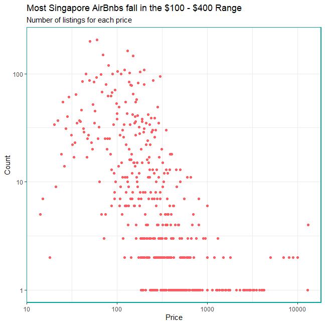

```r
log_price_hist <-
  ggplot(singapore_listings, aes(x= price))+
  geom_point(stat = "count",colour="#FF5A5F") +
   labs(x = "Price",
       y = "Count", title="Most Singapore AirBnbs fall in the $100 - $400 Range",subtitle="Number of listings for each price") +
  scale_x_log10()+
  scale_y_log10()+
  theme_bw()+
  theme(panel.border = element_rect(colour = "#00A699", fill=NA, size=1))

log_price_hist
```

A large majority of accomodations are concentrated below $250 USD.

### Visualise Extreme Data

In this part we are visualising our dataset using boxplots, in order to identify outliers and proceed with filtering our extreme values.

```r
# Observe extreme values

cleaning_box_1 <-
  ggplot(singapore_listings, aes(y=price)) +
  geom_boxplot(colour="#00A699")+
  labs(y="Price ($)")+
  theme(plot.title = element_text(face = "bold")) +
  theme(plot.subtitle = element_text(face = "bold", color = "grey35")) +
  theme(plot.caption = element_text(color = "grey68")) +
  NULL

cleaning_box_2 <-
  ggplot(singapore_listings, aes(y=minimum_nights)) +
  geom_boxplot(colour="#00A699")+
  labs(y="Minimum Nights")+
  theme(plot.title = element_text(face = "bold")) +
  theme(plot.subtitle = element_text(face = "bold", color = "grey35")) +
  theme(plot.caption = element_text(color = "grey68")) +
  NULL

cleaning_box_3 <-
  ggplot(singapore_listings, aes(y=cleaning_fee)) +
  geom_boxplot(colour="#00A699")+
  labs(y="Cleaning Fee ($)") +
  theme(plot.title = element_text(face = "bold")) +
  theme(plot.subtitle = element_text(face = "bold", color = "grey35")) +
  theme(plot.caption = element_text(color = "grey68")) +
  NULL

cleaning_box_4<-
  ggplot(singapore_listings, aes(y=extra_people)) +
  geom_boxplot(colour="#00A699")+
  labs(y="Fee for extra people ($)") +
  theme(plot.title = element_text(face = "bold")) +
  theme(plot.subtitle = element_text(face = "bold", color = "grey35")) +
  theme(plot.caption = element_text(color = "grey68")) +
  NULL

combined_box_plots <-
  ggarrange(cleaning_box_1,
            cleaning_box_2,
            cleaning_box_3,
            cleaning_box_4,
            ncol = 2, nrow = 2) +
  theme_bw()+
  theme(panel.border = element_rect(colour = "#FF5A5F", fill=NA, size=1))
  NULL
```

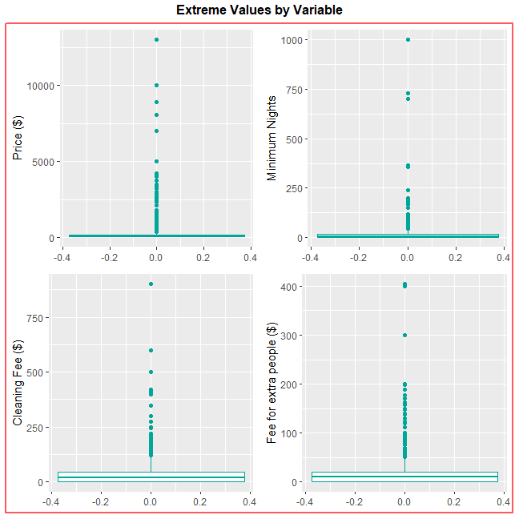

```r
annotate_figure(combined_box_plots, top = text_grob("Extreme Values by Variable", face = "bold"))
```

## Data Filtering

After looking at the above shown figures, we chose to filter the following variables:

1. Minimum nights to <= 4 nights
2. Price to <= $1500
3. Cleaning fee <= $200
4. Fee for extra people <= $100

Moreover, we determined the top 5 property types and allocated all other types into an “other” category.

```r
#Finding the most listed property types
top_property_types <- singapore_listings %>%
  group_by(property_type) %>%
  summarise(count = count(property_type)) %>%
  top_n(5)

#Adding column for the top 5 property types and categorising the rest as 'Other'
filtered_listings <- singapore_listings %>%
  mutate(prop_type_simplified = case_when(
    property_type %in% c("Apartment","Condominium", "Hostel","House", "Serviced apartment") ~ property_type,
    TRUE ~ "Other"
  ))

# Filter dataframe by minimum nights <= 4
filtered_listings <- filtered_listings %>%
  filter(minimum_nights <= 4, price <= 1500, cleaning_fee <= 200, extra_people <= 100)
```

## Correlation Matrix

```r
#regression analysis data set created here
regression_analysis <- filtered_listings %>%
  mutate(price_4_nights =
           price*4 +
           cleaning_fee +
           extra_people,
         log_4_nights = log10(price_4_nights)
         )

#create correlation matrix for variables with data type "double"
correlation_matrix <- regression_analysis %>%
  summarise(
         cleaning_fee,
         extra_people,
         minimum_nights,
         number_of_reviews,
         review_scores_rating,
         review_scores_location,
         longitude,
         latitude,
         security_deposit,
         price_4_nights,
         log_4_nights)

#have a look on the correlation matrix data
glimpse(correlation_matrix)
```

```
## Rows: 3,648
## Columns: 11
## $ cleaning_fee           <dbl> 70, 15, 25, 63, 0, 35, 0, 0, 36, 0, 0, 0, 80...
## $ extra_people           <dbl> 35, 25, 14, 0, 0, 15, 0, 0, 0, 0, 0, 0, 0, 3...
## $ minimum_nights         <dbl> 1, 2, 2, 4, 2, 1, 1, 1, 3, 2, 2, 1, 1, 2, 1,...
## $ number_of_reviews      <dbl> 29, 82, 29, 11, 69, 36, 0, 0, 1, 40, 70, 0, ...
## $ review_scores_rating   <dbl> 82, 94, 92, 91, 94, 94, NA, NA, 100, 96, 91,...
## $ review_scores_location <dbl> 9, 9, 9, 9, 10, 9, NA, NA, 10, 10, 10, NA, 9...
## $ longitude              <dbl> 104, 104, 104, 104, 104, 104, 104, 104, 104,...
## $ latitude               <dbl> 1.34, 1.36, 1.34, 1.33, 1.30, 1.35, 1.38, 1....
## $ security_deposit       <dbl> 279, 140, 279, 1398, 500, 0, 0, 0, 0, 500, 5...
## $ price_4_nights         <dbl> 941, 264, 263, 1175, 660, 222, 820, 672, 552...
## $ log_4_nights           <dbl> 2.97, 2.42, 2.42, 3.07, 2.82, 2.35, 2.91, 2....
```

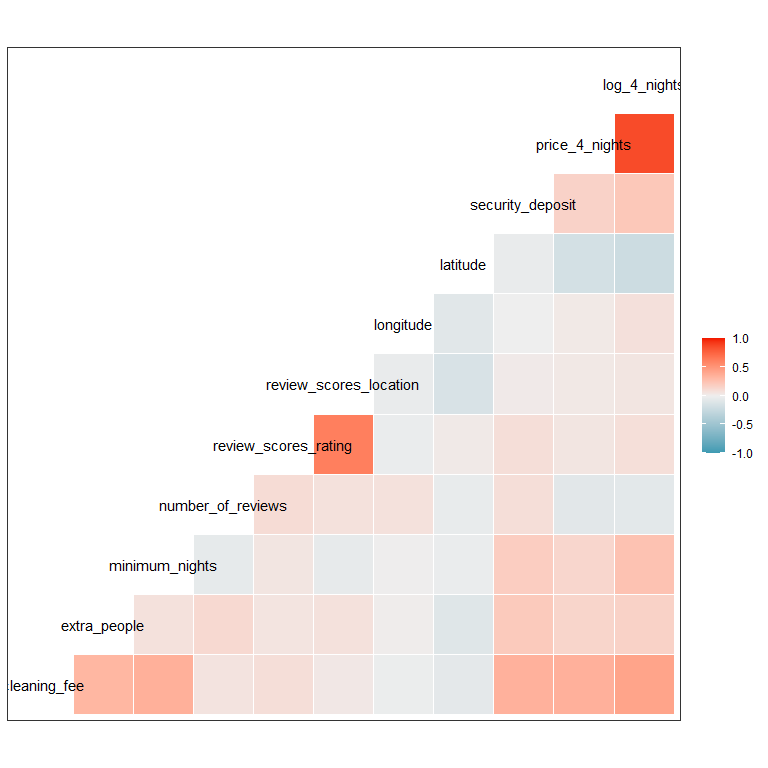

```r
#glance at the correlation relationship between different variables
ggcorr(correlation_matrix)+
  theme_bw() +
  NULL
```

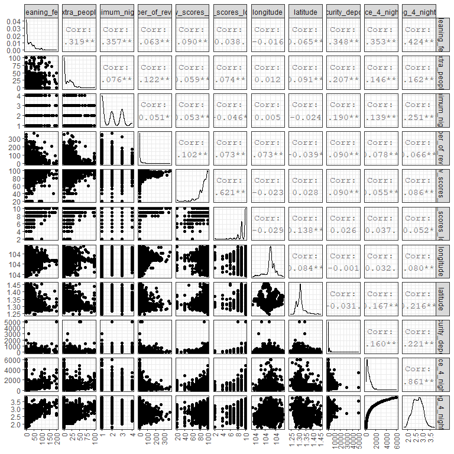

```r
#show the correlations more clearly
ggpairs(correlation_matrix, columns=1:11,
    upper=list(continuous='cor'),
    lower=list(continuous = 'points'),
    diag=list(continuous='density'),
    axisLabels='show') +
    theme_bw()+
    theme(axis.text.x = element_text(angle = 90, vjust = 0.5, hjust=1))
```

# Mapping

```r
#mapping visualisation for listings by price
pal <- colorNumeric(palette = "RdBu", domain = c(-100:1000))

map_1 <- leaflet(data = filtered_listings) %>%
  addProviderTiles("OpenStreetMap.Mapnik") %>%
  addCircleMarkers(lng = ~longitude,
                   lat = ~latitude,
                   radius = 1,
                   color = ~pal(price),
                   fillOpacity = 0.4,
                   label = ~price)
map_1
```

[interactive chart not shown]

[interactive chart not shown]

[interactive chart not shown]

# Let’s Visualize

## Scatterplots

To further investigate the relationship between the key variables We have created the following scatterplots:

- price VS number of reviews
- price VS review score
- price VS property type
- price VS room type
- price VS regions
- price VS bedrooms
- price VS number of people accomodates
- price VS cleaning fees

We started by plotting number of reviews versus price. It can be seen that having many reviews does not affect positively the price as one would expect. Ofcourse, other factors, such as the quality of reviews (e.g. negative or positive) and the overall competition of AirBns in Singapore cannot be determined, hence lowering the significance of the above relationship.

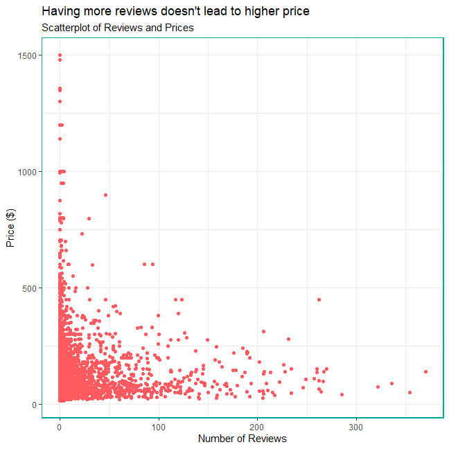

The next plot shows the price versus review scores. An interesting insight on the graph is that only after a review score of 95% does the price seem to have a positive tendency. This could potentially signify high competition of really good AirBnbs giving a pricing advantage only to hosts with extremely good reviews.

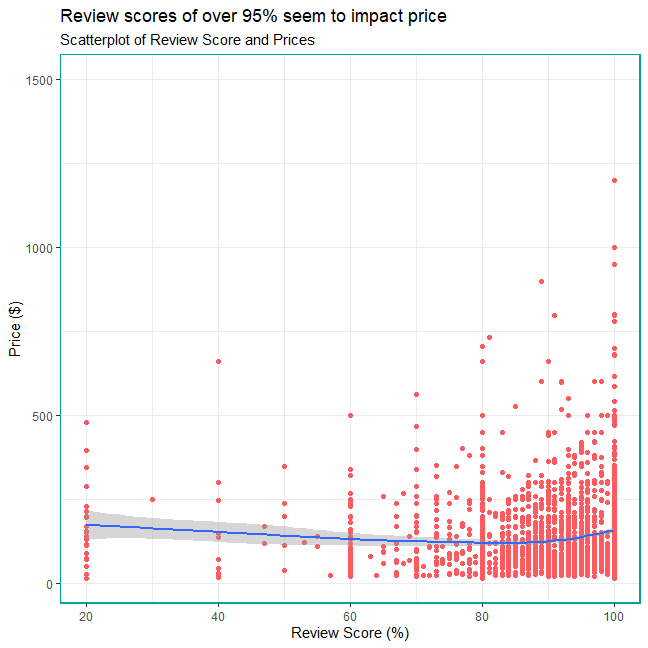

The next scatterplot shows the price versus the property type. We have simplified this data into the following variables: house, condominium, apartment, serviced apartment, hostel, and other. A general conclusion is difficult to be made, as most types of accommodations seem to hover around a similar range of prices. Nevertheless, serviced apartment prices start at a higher price level, which could signify an incentive for hosts to improve the quality of hospitality. Moreover, the price range of hostels as expected is lower than the rest, and finally, as expected, the range of prices for apartments and condominiums is quite high.

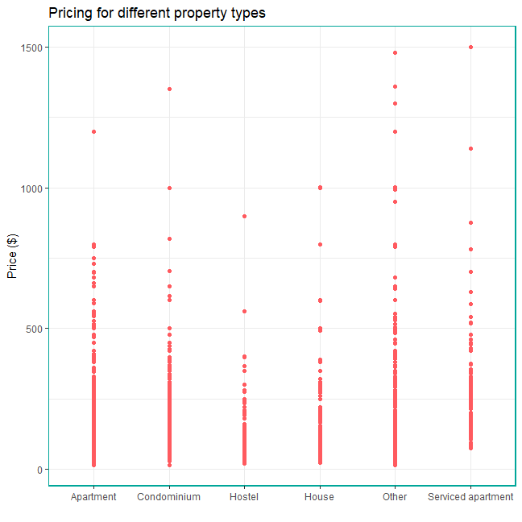

Next, we show the price versus the room type, and as expected entire homes and private rooms can reach a higher price. Nevertheless, what’s interesting is that a large part of the dataset is located on the lower end, hence having similar prices for shared, as well as private rooms.

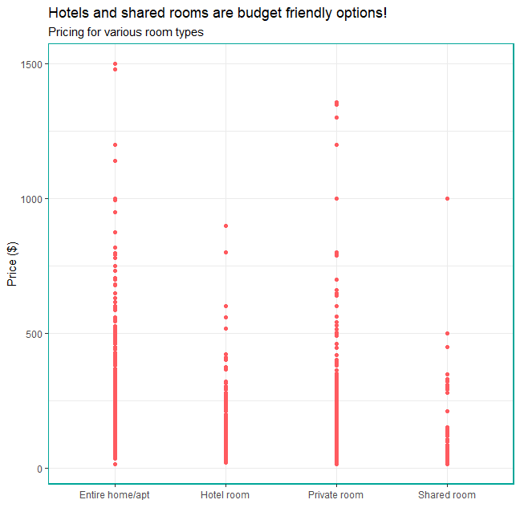

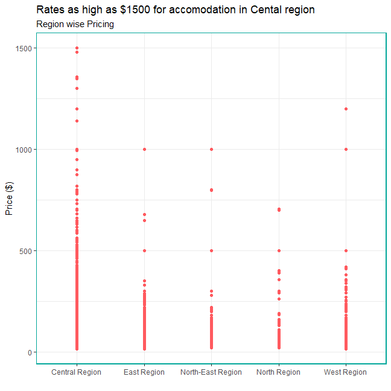

The following scatterplot shows the price versus the number of bedrooms. As the number of bedrooms increases, we can see that the price also increases slightly (excluding the brief dropoff near 7.5 bedrooms). This is unsurprising as larger properties tend to be more expensive. Moreover, the observed dropoff comes as a result of one datapoint and can be thus deemed not significant.

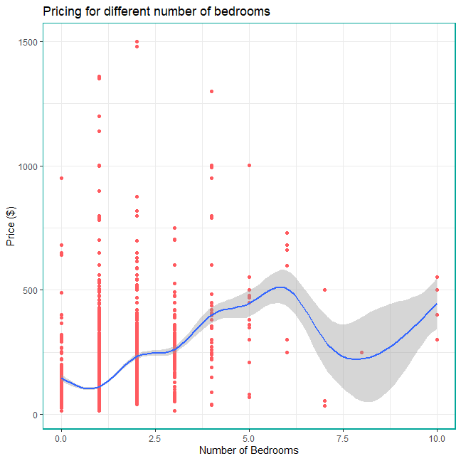

The next scatterplot shows the price versus the number of people the property accommodates. We would expect this plot to show a strong response from price, because usually if a property accommodates more people, it would be more expensive. The lack of a strong response could indicate that there is a large amount of smaller, luxury properties that are expensive, despite not accommodating many people. Additionally, it is possible that cheaper properties that can accommodate many people may be hostels.

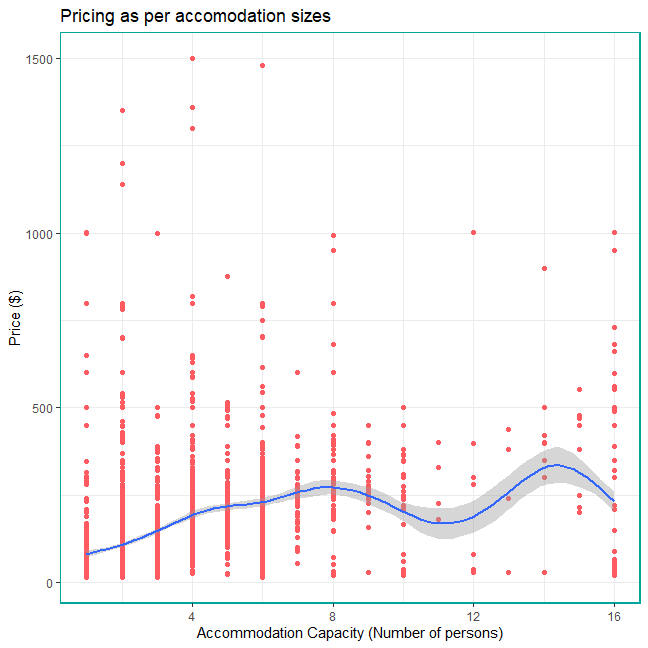

Finally, the last scatterplot graphically represents the relationship between Price and cleaning fee, which seem to have a positive relationship. The higher the prices the higher the cleaning fees. The data points along the horizontal axis are from hosts that do not charge for cleaning fee, however we cannot know whether they incorporate it inflating their overall price.

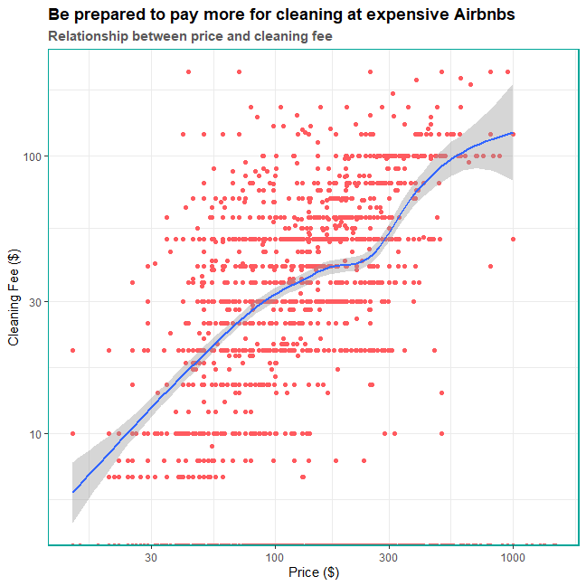